# Normal vs. t-distribution

```r
library(ggplot2)
```

# The normal distribution

Here I’m getting a sequence for x that consists of 500 evenly-spaced values between -4 and 4. I then get y, which is the value of the normal distribution probability density function for each value of x. Finally, I graph x and y together to visualize the normal distribution.

```r
set.seed(123)

x = seq(from = -4, to = 4, length.out = 500)
y_norm = dnorm(x)

data <- data.frame(x, y_norm)
```

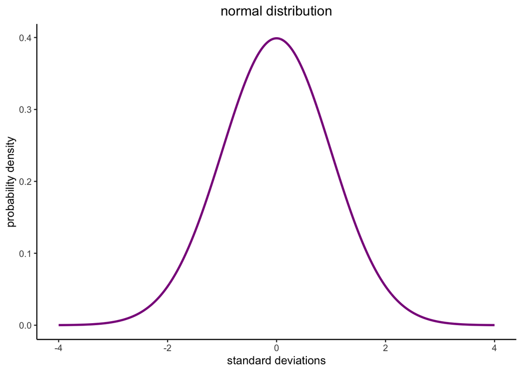

```r
ggplot(data, aes(x)) +
    geom_line(aes(y = y_norm), color = "magenta4", linewidth = 1) +

    theme_bw() +
    theme(axis.line = element_line(color='black'),
      plot.background = element_blank(),
      panel.grid.major = element_blank(),
      panel.grid.minor = element_blank(),
      panel.border = element_blank(),
      legend.title= element_blank(),
      plot.title = element_text(hjust = 0.5)) +

    labs(title = 'normal distribution', x = 'standard deviations', y = 'probability density')
```

# The t-distribution

Now let’s do the t-distribution at one degree of freedom. We’ll leave x the same, but y will now be the output of the t-distribution probability density function at the values of x and given the specified degrees of freedom.

```r
set.seed(123)

df <- 1
y1 <- dt(x, df)


data <- data.frame(x, y1)
```

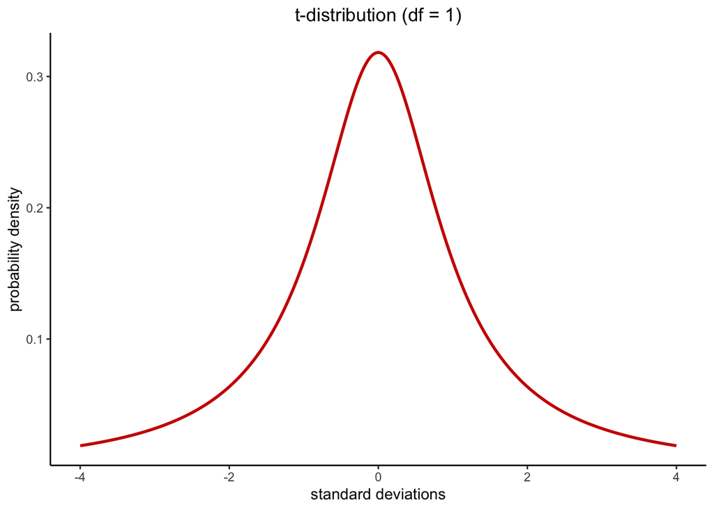

```r
ggplot(data, aes(x)) +
    geom_line(aes(y = y1), color = "red3", size = 1) +

    theme_bw() +
    theme(axis.line = element_line(color='black'),
      plot.background = element_blank(),
      panel.grid.major = element_blank(),
      panel.grid.minor = element_blank(),
      panel.border = element_blank(),
      legend.title= element_blank(),
      plot.title = element_text(hjust = 0.5)) +

    labs(title = 't-distribution (df = 1)', x = 'standard deviations', y = 'probability density')
```

# Comparing the normal to the t-distribution

Let’s generate some more outputs of the t-distribution probability density function but at different degrees of freedom.

```r
df <- 10
y10 <- dt(x, df)

df <- 30
y30 <- dt(x, df)

df <- 100
y100 <- dt(x, df)

df <- 1000
y1000 <- dt(x, df)
```

Now let’s put them all in a dataframe and do some comparison plots.

```r
df <- data.frame(x, y_norm, y1, y10, y30, y100, y1000)
```

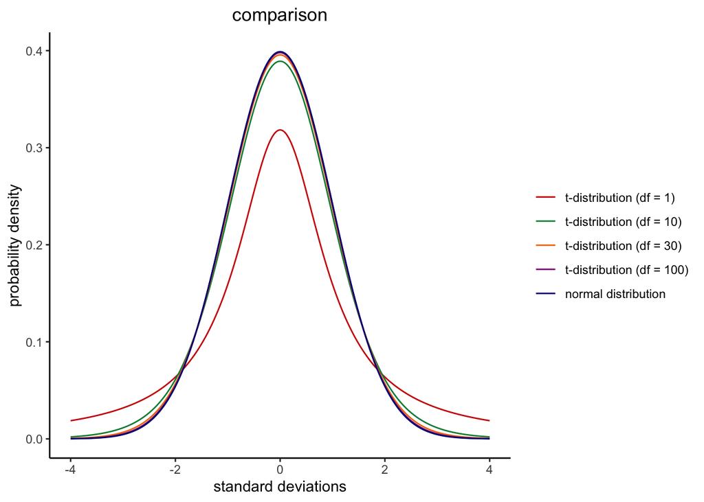

```r
ggplot(df, aes(x)) +
    geom_line(aes(y = y1, color = "t-distribution (df = 1)"), size = .5) +
    geom_line(aes(y = y10, color = "t-distribution (df = 10)")) +
    geom_line(aes(y = y30, color = "t-distribution (df = 30)"), size = .5) +
    geom_line(aes(y = y100, color = "t-distribution (df = 100)")) +
    geom_line(aes(y = y_norm, color = "normal distribution"), size = .5) +

    scale_color_manual(
                     breaks=c('t-distribution (df = 1)', 't-distribution (df = 10)', 't-distribution (df = 30)',
                             't-distribution (df = 100)', 'normal distribution'),
                     values=c('t-distribution (df = 1)'='red3', 't-distribution (df = 10)'='springgreen4', 't-distribution (df = 30)'='darkorange2',
                              't-distribution (df = 100)' = 'magenta4', 'normal distribution' = 'navyblue'))+
    theme_bw() +
    theme(axis.line = element_line(color='black'),
      plot.background = element_blank(),
      panel.grid.major = element_blank(),
      panel.grid.minor = element_blank(),
      panel.border = element_blank(),
      legend.title= element_blank(),
      plot.title = element_text(hjust = 0.5)) +

    labs(title = 'comparison', x = 'standard deviations', y = 'probability density')
```

I’ve satisfied myself that I’m still fine with the using the normal instead of the t-distribution when the sample size is large enough since at higher degrees of freedom, the t-distribution approximates the normal well. If the sample size is large enough the different between using the t-distribution vs. using the normal distribution is negligible, but it becomes more important to use the t-distribution as the sample size decreases.